# What Is Information Gain?

`Information Gain`, or `IG` for short, measures the reduction in `entropy` or surprise by splitting a dataset according to a given value of a random variable. A **larger information gain suggests a lower entropy** group or groups of samples, and hence less surprise.

`Entropy` quantifies how much information there is in a random variable, or more specifically its probability distribution. A skewed distribution has a low entropy, a distribution where events have equal probability will have larger entropy.

`Information gain` is commonly used in the construction of `decision trees` from a training dataset, by evaluating the information gain for each variable, and selecting the variable that maximizes the information gain between the parent node and its split nodes, which in turn `minimizes the entropy` and best splits the dataset into groups for best classification.

- In a binary case:
  - Entropy is `0` if **all samples belong to the same class** for a node (i.e., pure)
  - Entropy is `1` **samples contain both classes** for a node (i.e., 50% for each class awful)

[figure not shown]

Information quantifies how surprising an event is in bits. Lower probability events have more information, higher probability events have less information.

- **Skewed** Probability Distribution (unsurprising): Low entropy.
- **Balanced** Probability Distribution (surprising): High entropy.
- `Information gain` can also be used for `feature selection`, by evaluating the gain of each variable in the context of the target variable. In this slightly different usage, the calculation is referred to as `mutual information` between the two random variables.

### Entropy example

In a binary classification problem, we can calculate the entropy of the data sample as follows:

- Entropy = `-(p(0) * log(P(0)) + p(1) * log(P(1)))`

A dataset with a `50/50` split of samples for the two classes would have a maximum entropy (maximum surprise) of `1` bit, whereas an imbalanced dataset with a split of `10/90` would have a smaller entropy as there would be less surprise for a randomly drawn example from the dataset.

```python
# calculate the entropy for a dataset
from math import log2

# proportion of examples in each class
class0 = 10/100
class1 = 90/100

# calculate entropy
entropy = -(class0 * log2(class0) + class1 * log2(class1))

# print the result
print(f'Entropy: {round(entropy,3)} bits')
```

```
Entropy: 0.469 bits
```

`Entropy` can be used as a calculation of the purity of a dataset, e.g. how balanced the distribution of classes happens to be.

`Information gain` provides a way to use entropy to calculate how a change to the dataset impacts the purity of the dataset, e.g. the distribution of classes. A smaller entropy suggests more purity or less surprise.

## Calculating Information Gain

We can define a function to calculate the entropy of a group of samples based on the ratio of samples that belong to class `0` and class `1`.

```python
# calculate the entropy for the split in the dataset
def entropy(class0, class1):
    return -(class0 * log2(class0) + class1 * log2(class1))
```

Now, consider a dataset with `20` examples, `13` for class `0` and `7` for class `1`. We can calculate the entropy for this dataset, which will have less than `1` bit.

```python
# split of the main dataset
class0 = 13 / 20
class1 = 7 / 20

# calculate entropy before the change
s_entropy = entropy(class0, class1)
print('Dataset Entropy: %.3f bits' % s_entropy)
```

```
Dataset Entropy: 0.934 bits
```

Now consider that one of the variables in the dataset has `2` unique values, say `value1` and `value2`. We are interested in calculating the information gain of this variable.

Let’s assume that if we split the dataset by `value1`, we have a group of `8` samples, `7` for class `0` and `1` for class `1`. We can then calculate the entropy of this group of samples.

```python
# split 1 (split via value1)
s1_class0 = 7 / 8
s1_class1 = 1 / 8

# calculate the entropy of the first group
s1_entropy = entropy(s1_class0, s1_class1)
print('Group1 Entropy: %.3f bits' % s1_entropy)
```

```
Group1 Entropy: 0.544 bits
```

Now, let’s assume that we split the dataset by `value2`; we have a group of `12` samples with `6` in each group. We would expect this group to have an entropy of `1`.

```python
# split 2  (split via value2)
s2_class0 = 6 / 12
s2_class1 = 6 / 12

# calculate the entropy of the second group
s2_entropy = entropy(s2_class0, s2_class1)
print('Group2 Entropy: %.3f bits' % s2_entropy)
```

```
Group2 Entropy: 1.000 bits
```

Lastly, we can calculate the information gain for this variable based on the groups created for each value of the variable and the calculated entropy.

The first variable resulted in a group of `8` examples from the dataset, and the second group had the remaining `12` samples in the data set. Therefore, we have everything we need to calculate the information gain.

In this case, information gain can be calculated as:

- `Entropy(Dataset) – Count(Group1) / Count(Dataset) * Entropy(Group1) + Count(Group2) / Count(Dataset) * Entropy(Group2)`

Or:

- `Entropy(13/20, 7/20) – 8/20 * Entropy(7/8, 1/8) + 12/20 * Entropy(6/12, 6/12)`

```python
# calculate the information gain
gain = s_entropy - (8/20 * s1_entropy + 12/20 * s2_entropy)
print('Information Gain: %.3f bits' % gain)
```

```
Information Gain: 0.117 bits
```

# Using information theory to evaluate features

The `mutual information (MI)` between a feature and the outcome is a measure of the mutual dependence between the two variables. It extends the notion of correlation to nonlinear relationships. More specifically, it quantifies the information obtained about one random variable through the other random variable. MI determines how different the joint distribution of the pair **`(X,Y)`** is to the product of the marginal distributions of **`X`** and **`Y`**.

The sklearn function implements `feature_selection.mutual_info_regression` that computes the mutual information between all features and a continuous outcome to select the features that are most likely to contain predictive information. There is also a classification version (see the [documentation](https://scikit-learn.org/stable/modules/generated/sklearn.feature_selection.mutual_info_classif.html#sklearn.feature_selection.mutual_info_classif) for more details).

```python
%matplotlib inline
import warnings
from datetime import datetime
import os
from pathlib import Path
import quandl
import numpy as np
import matplotlib.pyplot as plt
import seaborn as sns
import pandas as pd
import pandas_datareader.data as web
from pandas_datareader.famafrench import get_available_datasets
from pyfinance.ols import PandasRollingOLS
from sklearn.feature_selection import mutual_info_classif
```

```python
warnings.filterwarnings('ignore')
sns.set(style="darkgrid", color_codes=True)
```

## Get Data

```python
'read'
with pd.HDFStore('/home/aj/Research Notebooks_py/Hands-On-Machine-Learning-for-Algorithmic-Trading/data/assets.h5', mode='r') as store:
    data = store['engineered_features']
```

```python
data.head()
```

| ticker | date | return_1m | return_2m | return_3m | return_6m | return_9m | return_12m | Mkt-RF | SMB | HML | RMW | ... | return_1m_t-4 | return_1m_t-5 | return_1m_t-6 | target_1m | target_2m | target_3m | target_6m | target_12m | msize | Sector |
| --- | --- | --- | --- | --- | --- | --- | --- | --- | --- | --- | --- | --- | --- | --- | --- | --- | --- | --- | --- | --- | --- | --- |
| AAL | 2006-09-30 | 0.049231 | -0.014995 | -0.042760 | 0.017278 | 0.019858 | 0.064198 | 0.138863 | 2.373876 | -0.901034 | -0.830475 | ... | NaN | NaN | NaN | 0.124746 | 0.131546 | 0.066996 | 0.004278 | -0.042727 | 10 | Industrials |
|  | 2006-10-31 | 0.124746 | 0.086333 | 0.029541 | 0.023947 | 0.060689 | 0.060353 | 0.138863 | 2.373876 | -0.901034 | -0.830475 | ... | NaN | NaN | NaN | 0.138387 | 0.039242 | 0.039346 | -0.048759 | -0.047917 | 10 | Industrials |
|  | 2006-11-30 | 0.138387 | 0.131546 | 0.103414 | 0.033049 | 0.061789 | 0.044687 | 0.138863 | 2.373876 | -0.901034 | -0.830475 | ... | NaN | NaN | NaN | -0.051268 | -0.006895 | -0.026972 | -0.074586 | -0.080364 | 10 | Industrials |
|  | 2006-12-31 | -0.051268 | 0.039242 | 0.066996 | 0.010629 | 0.033588 | 0.031443 | 0.138863 | 2.373876 | -0.901034 | -0.830475 | ... | NaN | NaN | NaN | 0.039554 | -0.014591 | -0.054754 | -0.091543 | -0.102498 | 10 | Industrials |
|  | 2007-01-31 | 0.039554 | -0.006895 | 0.039346 | 0.034432 | 0.029055 | 0.055312 | 0.138863 | 2.373876 | -0.901034 | -0.830475 | ... | 0.049231 | NaN | NaN | -0.065916 | -0.098649 | -0.129395 | -0.093757 | -0.109928 | 10 | Industrials |

5 rows × 32 columns

```python
data.info()
```

```
<class 'pandas.core.frame.DataFrame'>
MultiIndex: 323338 entries, (AAL, 2006-09-30 00:00:00) to (ZUMZ, 2018-02-28 00:00:00)
Data columns (total 32 columns):
return_1m        323338 non-null float64
return_2m        323338 non-null float64
return_3m        323338 non-null float64
return_6m        323338 non-null float64
return_9m        323338 non-null float64
return_12m       323338 non-null float64
Mkt-RF           323338 non-null float64
SMB              323338 non-null float64
HML              323338 non-null float64
RMW              323338 non-null float64
CMA              323338 non-null float64
momentum_2       323338 non-null float64
momentum_3       323338 non-null float64
momentum_6       323338 non-null float64
momentum_9       323338 non-null float64
momentum_12      323338 non-null float64
momentum_3_12    323338 non-null float64
year             323338 non-null int64
month            323338 non-null int64
return_1m_t-1    321688 non-null float64
return_1m_t-2    320038 non-null float64
return_1m_t-3    318388 non-null float64
return_1m_t-4    316738 non-null float64
return_1m_t-5    315088 non-null float64
return_1m_t-6    313438 non-null float64
target_1m        323338 non-null float64
target_2m        321688 non-null float64
target_3m        320038 non-null float64
target_6m        315088 non-null float64
target_12m       305188 non-null float64
msize            323338 non-null int64
Sector           323338 non-null object
dtypes: float64(28), int64(3), object(1)
memory usage: 80.3+ MB
```

```python
data.isna().sum()
```

```
return_1m            0
return_2m            0
return_3m            0
return_6m            0
return_9m            0
return_12m           0
Mkt-RF               0
SMB                  0
HML                  0
RMW                  0
CMA                  0
momentum_2           0
momentum_3           0
momentum_6           0
momentum_9           0
momentum_12          0
momentum_3_12        0
year                 0
month                0
return_1m_t-1     1650
return_1m_t-2     3300
return_1m_t-3     4950
return_1m_t-4     6600
return_1m_t-5     8250
return_1m_t-6     9900
target_1m            0
target_2m         1650
target_3m         3300
target_6m         8250
target_12m       18150
msize                0
Sector               0
dtype: int64
```

```python
data = data.dropna()
data.info()
```

```
<class 'pandas.core.frame.DataFrame'>
MultiIndex: 295288 entries, (AAL, 2007-03-31 00:00:00) to (ZUMZ, 2017-03-31 00:00:00)
Data columns (total 32 columns):
return_1m        295288 non-null float64
return_2m        295288 non-null float64
return_3m        295288 non-null float64
return_6m        295288 non-null float64
return_9m        295288 non-null float64
return_12m       295288 non-null float64
Mkt-RF           295288 non-null float64
SMB              295288 non-null float64
HML              295288 non-null float64
RMW              295288 non-null float64
CMA              295288 non-null float64
momentum_2       295288 non-null float64
momentum_3       295288 non-null float64
momentum_6       295288 non-null float64
momentum_9       295288 non-null float64
momentum_12      295288 non-null float64
momentum_3_12    295288 non-null float64
year             295288 non-null int64
month            295288 non-null int64
return_1m_t-1    295288 non-null float64
return_1m_t-2    295288 non-null float64
return_1m_t-3    295288 non-null float64
return_1m_t-4    295288 non-null float64
return_1m_t-5    295288 non-null float64
return_1m_t-6    295288 non-null float64
target_1m        295288 non-null float64
target_2m        295288 non-null float64
target_3m        295288 non-null float64
target_6m        295288 non-null float64
target_12m       295288 non-null float64
msize            295288 non-null int64
Sector           295288 non-null object
dtypes: float64(28), int64(3), object(1)
memory usage: 73.2+ MB
```

## Create Dummy variables

```python
dummy_data = pd.get_dummies(data,
                            columns=['year','month', 'msize', 'Sector'],
                            prefix=['year','month', 'msize', ''],
                            prefix_sep=['_', '_', '_', ''])
dummy_data = dummy_data.rename(columns={c:c.replace('.0', '') for c in dummy_data.columns})
dummy_data.info()
```

```
<class 'pandas.core.frame.DataFrame'>
MultiIndex: 295288 entries, (AAL, 2007-03-31 00:00:00) to (ZUMZ, 2017-03-31 00:00:00)
Data columns (total 79 columns):
return_1m                 295288 non-null float64
return_2m                 295288 non-null float64
return_3m                 295288 non-null float64
return_6m                 295288 non-null float64
return_9m                 295288 non-null float64
return_12m                295288 non-null float64
Mkt-RF                    295288 non-null float64
SMB                       295288 non-null float64
HML                       295288 non-null float64
RMW                       295288 non-null float64
CMA                       295288 non-null float64
momentum_2                295288 non-null float64
momentum_3                295288 non-null float64
momentum_6                295288 non-null float64
momentum_9                295288 non-null float64
momentum_12               295288 non-null float64
momentum_3_12             295288 non-null float64
return_1m_t-1             295288 non-null float64
return_1m_t-2             295288 non-null float64
return_1m_t-3             295288 non-null float64
return_1m_t-4             295288 non-null float64
return_1m_t-5             295288 non-null float64
return_1m_t-6             295288 non-null float64
target_1m                 295288 non-null float64
target_2m                 295288 non-null float64
target_3m                 295288 non-null float64
target_6m                 295288 non-null float64
target_12m                295288 non-null float64
year_2001                 295288 non-null uint8
year_2002                 295288 non-null uint8
year_2003                 295288 non-null uint8
year_2004                 295288 non-null uint8
year_2005                 295288 non-null uint8
year_2006                 295288 non-null uint8
year_2007                 295288 non-null uint8
year_2008                 295288 non-null uint8
year_2009                 295288 non-null uint8
```

[output cut: 29 more lines]

```
msize_10                  295288 non-null uint8
Basic Materials           295288 non-null uint8
Communication Services    295288 non-null uint8
Consumer Cyclical         295288 non-null uint8
Consumer Defensive        295288 non-null uint8
Energy                    295288 non-null uint8
Financial Services        295288 non-null uint8
Healthcare                295288 non-null uint8
Industrial Goods          295288 non-null uint8
Industrials               295288 non-null uint8
Real Estate               295288 non-null uint8
Technology                295288 non-null uint8
Utilities                 295288 non-null uint8
dtypes: float64(28), uint8(51)
memory usage: 78.6+ MB
```

```python
dummy_data.head()
```

| ticker | date | return_1m | return_2m | return_3m | return_6m | return_9m | return_12m | Mkt-RF | SMB | HML | RMW | ... | Consumer Cyclical | Consumer Defensive | Energy | Financial Services | Healthcare | Industrial Goods | Industrials | Real Estate | Technology | Utilities |
| --- | --- | --- | --- | --- | --- | --- | --- | --- | --- | --- | --- | --- | --- | --- | --- | --- | --- | --- | --- | --- | --- | --- |
| AAL | 2007-03-31 | -0.130235 | -0.098649 | -0.054754 | 0.004278 | -0.011653 | 0.010757 | 0.138863 | 2.373876 | -0.901034 | -0.830475 | ... | 0 | 0 | 0 | 0 | 0 | 0 | 1 | 0 | 0 | 0 |
|  | 2007-04-30 | -0.187775 | -0.159497 | -0.129395 | -0.048759 | -0.023344 | -0.013075 | 0.138863 | 2.373876 | -0.901034 | -0.830475 | ... | 0 | 0 | 0 | 0 | 0 | 0 | 1 | 0 | 0 | 0 |
|  | 2007-05-31 | -0.034921 | -0.114641 | -0.119870 | -0.074586 | -0.018696 | -0.022248 | 0.138863 | 2.373876 | -0.901034 | -0.830475 | ... | 0 | 0 | 0 | 0 | 0 | 0 | 1 | 0 | 0 | 0 |
|  | 2007-06-30 | -0.150912 | -0.094772 | -0.126900 | -0.091543 | -0.041504 | -0.041818 | 0.138863 | 2.373876 | -0.901034 | -0.830475 | ... | 0 | 0 | 0 | 0 | 0 | 0 | 1 | 0 | 0 | 0 |
|  | 2007-07-31 | 0.024447 | -0.067345 | -0.056660 | -0.093757 | -0.051400 | -0.031781 | 0.138863 | 2.373876 | -0.901034 | -0.830475 | ... | 0 | 0 | 0 | 0 | 0 | 0 | 1 | 0 | 0 | 0 |

5 rows × 79 columns

```python
dummy_data.describe()
```

|  | return_1m | return_2m | return_3m | return_6m | return_9m | return_12m | Mkt-RF | SMB | HML | RMW | ... | Consumer Cyclical | Consumer Defensive | Energy | Financial Services | Healthcare | Industrial Goods | Industrials | Real Estate | Technology | Utilities |
| --- | --- | --- | --- | --- | --- | --- | --- | --- | --- | --- | --- | --- | --- | --- | --- | --- | --- | --- | --- | --- | --- |
| count | 295288.000000 | 295288.000000 | 295288.000000 | 295288.000000 | 295288.000000 | 295288.000000 | 295288.000000 | 295288.000000 | 295288.000000 | 295288.000000 | ... | 295288.000000 | 295288.000000 | 295288.000000 | 295288.000000 | 295288.000000 | 295288.000000 | 295288.000000 | 295288.000000 | 295288.000000 | 295288.000000 |
| mean | 0.012364 | 0.009287 | 0.008322 | 0.007270 | 0.006870 | 0.006551 | 0.977150 | 0.626099 | 0.129970 | -0.056357 | ... | 0.128197 | 0.051231 | 0.054442 | 0.172716 | 0.118186 | 0.000640 | 0.171609 | 0.058147 | 0.120130 | 0.034597 |
| std | 0.112866 | 0.080281 | 0.065998 | 0.047945 | 0.039451 | 0.034315 | 0.863596 | 1.210207 | 1.512535 | 1.919062 | ... | 0.334309 | 0.220470 | 0.226888 | 0.378002 | 0.322829 | 0.025291 | 0.377041 | 0.234021 | 0.325114 | 0.182756 |
| min | -0.325956 | -0.251753 | -0.211078 | -0.159002 | -0.129920 | -0.112127 | -9.311845 | -10.159771 | -13.036170 | -24.698688 | ... | 0.000000 | 0.000000 | 0.000000 | 0.000000 | 0.000000 | 0.000000 | 0.000000 | 0.000000 | 0.000000 | 0.000000 |
| 25% | -0.046016 | -0.030430 | -0.023723 | -0.014675 | -0.010906 | -0.008809 | 0.500507 | -0.074166 | -0.642750 | -0.929064 | ... | 0.000000 | 0.000000 | 0.000000 | 0.000000 | 0.000000 | 0.000000 | 0.000000 | 0.000000 | 0.000000 | 0.000000 |
| 50% | 0.009954 | 0.010063 | 0.010004 | 0.009447 | 0.009114 | 0.008774 | 0.932280 | 0.557657 | 0.102173 | 0.049917 | ... | 0.000000 | 0.000000 | 0.000000 | 0.000000 | 0.000000 | 0.000000 | 0.000000 | 0.000000 | 0.000000 | 0.000000 |
| 75% | 0.066210 | 0.049401 | 0.042274 | 0.032073 | 0.027288 | 0.024564 | 1.413691 | 1.257672 | 0.875003 | 0.915518 | ... | 0.000000 | 0.000000 | 0.000000 | 0.000000 | 0.000000 | 0.000000 | 0.000000 | 0.000000 | 0.000000 | 0.000000 |
| max | 0.428079 | 0.279401 | 0.219990 | 0.153115 | 0.123644 | 0.105678 | 10.407951 | 10.212963 | 13.111228 | 17.643528 | ... | 1.000000 | 1.000000 | 1.000000 | 1.000000 | 1.000000 | 1.000000 | 1.000000 | 1.000000 | 1.000000 | 1.000000 |

8 rows × 79 columns

## Mutual Information

### Original Data

```python
target_labels = [f'target_{i}m' for i in [1,2,3,6,12]]
targets = data.dropna().loc[:, target_labels]

features = data.dropna().drop(target_labels, axis=1)
features.Sector = pd.factorize(features.Sector)[0]

cat_cols = ['year', 'month', 'msize', 'Sector']
discrete_features = [features.columns.get_loc(c) for c in cat_cols]
```

```python
mutual_info = pd.DataFrame()
for label in target_labels:
    mi = mutual_info_classif(X=features,
                             y=(targets[label]>0).astype(int),
                             discrete_features=discrete_features,
                             random_state=42
                            )
    mutual_info[label] = pd.Series(mi, index=features.columns)
```

```python
mutual_info.sum()
```

```
target_1m     0.036124
target_2m     0.062342
target_3m     0.089524
target_6m     0.138216
target_12m    0.209336
dtype: float64
```

### Normalized MI Heatmap

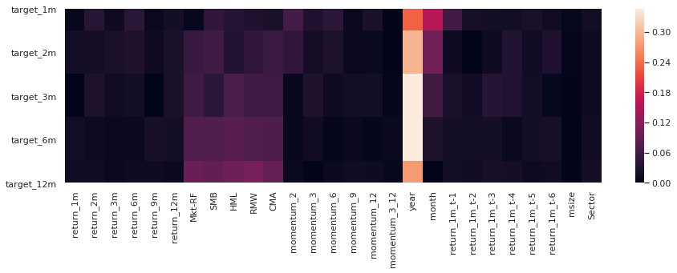

```python
fig, ax= plt.subplots(figsize=(15, 4))
sns.heatmap(mutual_info.div(mutual_info.sum()).T, ax=ax);
```

### Dummy Data

```python
target_labels = [f'target_{i}m' for i in [1, 2, 3, 6, 12]]
dummy_targets = dummy_data.dropna().loc[:, target_labels]

dummy_features = dummy_data.dropna().drop(target_labels, axis=1)
cat_cols = [c for c in dummy_features.columns if c not in features.columns]
discrete_features = [dummy_features.columns.get_loc(c) for c in cat_cols]
```

```python
mutual_info_dummies = pd.DataFrame()
for label in target_labels:
    mi = mutual_info_classif(X=dummy_features,
                             y=(dummy_targets[label]> 0).astype(int),
                             discrete_features=discrete_features,
                             random_state=42
                            )
    mutual_info_dummies[label] = pd.Series(mi, index=dummy_features.columns)
```

```python
mutual_info_dummies.sum()
```

```
target_1m     0.037281
target_2m     0.064253
target_3m     0.092183
target_6m     0.141994
target_12m    0.213704
dtype: float64
```

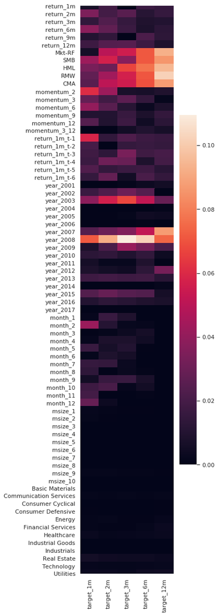

```python
fig, ax= plt.subplots(figsize=(4, 20))
sns.heatmap(mutual_info_dummies.div(mutual_info_dummies.sum()), ax=ax);
```